# Project Name Here

### Step 2: Repeat the analysis for the other study

```r
# Version info: R 3.2.3, Biobase 2.30.0, GEOquery 2.40.0, limma 3.26.8
# R scripts generated  Thu Mar 28 05:38:05 EDT 2019
################################################################
#   Differential expression analysis with limma
library(Biobase)
library(GEOquery)
library(limma)
# load series and platform data from GEO
gset <- getGEO("GSE14671", GSEMatrix =TRUE, AnnotGPL=TRUE)
```

```
Found 1 file(s)
GSE14671_series_matrix.txt.gz
Using locally cached version: /var/folders/_6/z0dk_wj97396pxknwtg8gmbc0000gn/T//RtmpMSX6zr/GSE14671_series_matrix.txt.gz
```

```r
tT <- subset(tT, select=c("ID","adj.P.Val","P.Value","Gene.symbol","Gene.title","Gene.ID","GO.Function","GO.Process"))
write.table(head(tT, file=stdout(), row.names=F, sep="\t"))
```

```
"ID" "adj.P.Val" "P.Value" "Gene.symbol" "Gene.title" "Gene.ID" "GO.Function" "GO.Process"
"40612_at" "40612_at" 0.886489859828241 4.28338670721571e-05 "DOPEY1" "dopey family member 1" "23033" "" "protein transport"
"216944_s_at" "216944_s_at" 0.886489859828241 9.75579674293235e-05 "ITPR1" "inositol 1,4,5-trisphosphate receptor type 1" "3708" "calcium channel inhibitor activity///calcium ion transmembrane transporter activity///calcium-release channel activity///inositol 1,4,5-trisphosphate-sensitive calcium-re…
"223325_at" "223325_at" 0.886489859828241 0.000132743036337203 "TXNDC11" "thioredoxin domain containing 11" "51061" "protein binding///protein disulfide isomerase activity" "cell redox homeostasis///protein folding///response to endoplasmic reticulum stress"
"228411_at" "228411_at" 0.886489859828241 0.00013866443214503 "PARD3B" "par-3 family cell polarity regulator beta" "117583" "" "cell cycle///cell division"
"1556346_at" "1556346_at" 0.886489859828241 0.000150695724736774 "COTL1" "coactosin like F-actin binding protein 1" "23406" "actin binding///enzyme binding///protein binding" "biological_process///defense response to fungus"
"227314_at" "227314_at" 0.886489859828241 0.000154158404755628 "ITGA2" "integrin subunit alpha 2" "3673" "collagen binding///collagen binding involved in cell-matrix adhesion///collagen receptor activity///integrin binding///laminin binding///metal ion binding///protein binding///protein complex bin…
```

the “profile graph” didn’t quite work as nicely (the Radich study, just had to enter one of the internal gene IDs). Here, it required opening a spearate file to look for the ID to profile.

“This tab allows you to view a specific gene expression profile graph by entering the corresponding identifier from the ID column of the Platform record. This feature does not perform any calculations; it merely displays the expression values of the gene across Samples. Sample groups may or may not be defined for this feature to work.”

```r
################################################################
#   Boxplot for selected GEO samples
library(Biobase)
library(GEOquery)
# load series and platform data from GEO
gset <- getGEO("GSE14671", GSEMatrix =TRUE, getGPL=FALSE)
```

```
Found 1 file(s)
GSE14671_series_matrix.txt.gz
Using locally cached version: /var/folders/_6/z0dk_wj97396pxknwtg8gmbc0000gn/T//RtmpMSX6zr/GSE14671_series_matrix.txt.gz
```

```r
if (length(gset) > 1) idx <- grep("GPL570", attr(gset, "names")) else idx <- 1
gset <- gset[[idx]]
# group names for all samples in a series
gsms <- "33333333333344444444444444444444444433333344444444444444444"
sml <- c()
for (i in 1:nchar(gsms)) { sml[i] <- substr(gsms,i,i) }
sml <- paste("G", sml, sep="")  #set group names
# order samples by group
ex <- exprs(gset)[ , order(sml)]
sml <- sml[order(sml)]
fl <- as.factor(sml)
labels <- c("cd","ap","bc","resistant","responder")
```

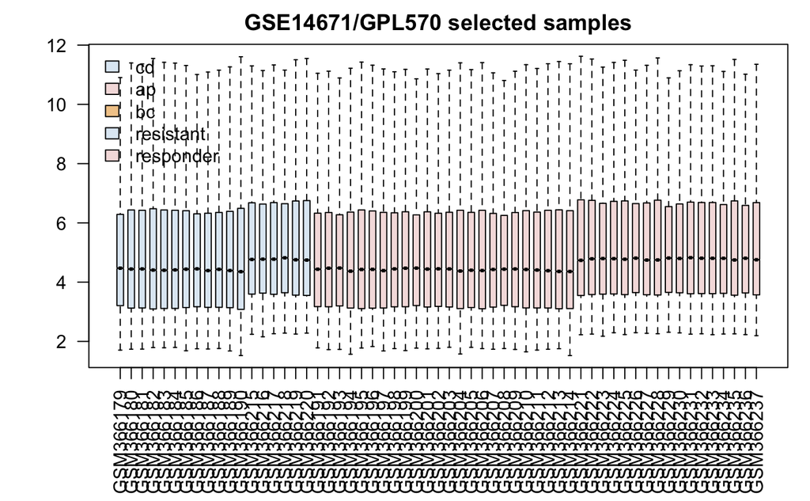

```r
# set parameters and draw the plot
palette(c("#dfeaf4","#f4dfdf","#f2cb98","#dfeaf4","#f4dfdf", "#AABBCC"))
dev.new(width=4+dim(gset)[[2]]/5, height=6)
par(mar=c(2+round(max(nchar(sampleNames(gset)))/2),4,2,1))
title <- paste ("GSE14671", '/', annotation(gset), " selected samples", sep ='')
boxplot(ex, boxwex=0.6, notch=T, main=title, outline=FALSE, las=2, col=fl)
legend("topleft", labels, fill=palette(), bty="n")
```

So, both datasets are loaded. They total less than 80MB each. Would be more interesting to eventually get gene-level info (splits by funcitonal pathway,etc).

But first step is to aggregate the 2 datasets together. Questions to ask: are the ranges and distributions the same for both datasets, roughly? Do the 2 populations look similar in terms of value range or even distribution (bimodal, normal, etc)? *If not very similar… is there similarity WITHIN the populations of one study? or is the population within a study as ~heterogeneious as when compared ‘across’ studies?

+do i need to normalize the ranges or what? to get similaris distributions…?

NExt, are the “top 250” genes identified by the GEO2R default comparison… how similar is the “top 250” lists for the 2 studies? *This will lead naturally into a categorization of the genes in the 3 main pathways of interest. May also want to see highly expressed genes vs. normal patient levels (which should… highlight more genes that are members of the 3 pathways, id think)